# TP N°2 de Enfoque Estadístico del Aprendizaje: CART

Natalia Argento y Lautaro Fernández

6 de Diciembre de 2021

## Introducción

Los datos con los que se trabajará en este trabajo provienen de un Juego de Simulación de Fútbol, llamado Football manager (edición 2020), que se pueden acceder a través de este link en Kaggle: https://www.kaggle.com/ktyptorio/football-manager-2020. En este dataset se encuentran los datos de los jugadores de las principales ligas de fútbol del planeta. Para acotar el análisis nos decidimos centrar en el fútbol de Argentina. Entre otras variables, podemos mencionar el peso, la altura, la edad, el club, el sueldo, las posiciones en las que puede jugar, la calificación dentro del juego y la calificación máxima que puede aspirar el jugador dentro del juego, entre otros atributos que marcan las habilidades del jugador.

El objetivo general del documento es aplicar un modelo de árboles de regresión predecir el **sueldo** de los jugadores según la información más relevante del dataset.

## Ambiente de trabajo

Limpiamos entorno

```r
rm( list=ls() )
gc()
```

```
##          used (Mb) gc trigger (Mb) max used (Mb)
## Ncells 462774 24.8    1000355 53.5   643711 34.4
## Vcells 834806  6.4    8388608 64.0  1650728 12.6
```

Seteamos una semilla

```r
seed = 270793
set.seed(seed)
```

Cargamos las librerías que se usarán.

```r
library(rpart)
library(tidyverse)
library(tidymodels)
library(ggplot2)
library(funModeling)
library(Hmisc)
library(GGally)
library(rpart.plot)
library(rattle)
library(caret)
library(yardstick)
library(MASS)
library(broom)
library(purrr)
```

## 1) Cargamos y trabajamos los datos

Definimos el path donde encontrar el dataset

```r
setwd("~/EEA/TP2")
arch_jugadores = 'datafm20.csv'
arch_posiciones = 'equivalencia_posiciones.csv'
```

Leemos los datsets que usaremos

```r
df_players_crudo = read.csv(arch_jugadores, header = TRUE, sep = ',', encoding = 'utf-8')
df_equivalencia_posiciones = read.csv(arch_posiciones, header = TRUE, sep = ',', encoding = 'utf-8')
```

Mostramos las primeras filas de dataset de jugadores

```r
head(df_players_crudo, 10)
```

|  | X | Name | Position | Club | Division | Based | Nation | Height | Weight | Age | Preferred.Foot | Best.Pos | Best.Role | Value | Wage | CA | PA | Wor | Vis | Thr | Tec | Tea | Tck | Str | Sta | TRO | Ref | Pun | Pos | … |
| --- | --- | --- | --- | --- | --- | --- | --- | --- | --- | --- | --- | --- | --- | --- | --- | --- | --- | --- | --- | --- | --- | --- | --- | --- | --- | --- | --- | --- | --- | --- |
| 1 | 0 | Lionel Messi | AM (RC), ST (C) | Barcelona | Spanish First Division | Spain (First Division) | ARG | 170 | 72 | 32 | Left | AM (R) | IF | 73000000 | 1200000 | 195 | 200 | 7 | 20 | 2 | 20 | 14 | 7 | 9 | 13 | 3 | 1 | 2 | 5 | … |
| 2 | 1 | Cristiano Ronaldo | AM (RL), ST (C) | Juventus | Italian Serie A | Italy (Serie A) | POR | 185 | 83 | 34 | Either | ST (C) | CF | 31000000 | 950000 | 195 | 196 | 10 | 14 | 2 | 17 | 10 | 8 | 16 | 15 | 3 | 2 | 2 | 6 | … |
| 3 | 2 | Kylian MbappÃ© | AM (RL), ST (C) | Paris SG | Ligue 1 Conforama | France (Ligue 1 Conforama) | FRA | 178 | 73 | 20 | Right | ST (C) | AF | 86000000 | 375000 | 181 | 196 | 10 | 13 | 1 | 17 | 10 | 2 | 11 | 14 | 2 | 1 | 1 | 2 | … |
| 4 | 3 | Manuel Neuer | GK | FC Bayern | Bundesliga | Germany (Bundesliga) | GER | 192 | 90 | 33 | Either | GK | SK | 44000000 | 250000 | 176 | 193 | 14 | 12 | 19 | 12 | 18 | 3 | 16 | 10 | 20 | 14 | 8 | 15 | … |
| 5 | 4 | Neymar | M (L), AM (LC), ST (C) | Paris SG | Ligue 1 Conforama | France (Ligue 1 Conforama) | BRA | 175 | 68 | 27 | Right | AM (L) | IW | 91000000 | 600000 | 186 | 190 | 10 | 16 | 1 | 20 | 8 | 1 | 10 | 13 | 1 | 4 | 2 | 2 | … |
| 6 | 5 | Erling Haaland | ST (C) | Borussia Dortmund | Bundesliga | Germany (Bundesliga) | NOR | 194 | 87 | 18 | Left | ST (C) | AF | 67000000 | 135000 | 166 | 189 | 13 | 13 | 2 | 14 | 11 | 7 | 17 | 13 | 2 | 4 | 3 | 7 | … |
| 7 | 6 | Kevin De Bruyne | M (RLC), AM (C) | Man City | English Premier Division | England (Premier Division) | BEL | 181 | 70 | 27 | Either | M (C) | MEZ | 88000000 | 230000 | 188 | 188 | 15 | 20 | 3 | 17 | 14 | 9 | 13 | 17 | 2 | 3 | 1 | 9 | … |
| 8 | 7 | Luis SuÃ¡rez | AM (RLC), ST (C) | A. Madrid | Spanish First Division | Spain (First Division) | URU | 182 | 86 | 32 | Right | ST (C) | DLF | 55000000 | 245000 | 180 | 188 | 16 | 16 | 2 | 17 | 15 | 10 | 13 | 15 | 3 | 3 | 3 | 10 | … |
| 9 | 8 | Gianluigi Buffon | GK | Juventus | Italian Serie A | Italy (Serie A) | ITA | 192 | 92 | 41 | Right Only | GK | SK | 3100000 | 38000 | 156 | 187 | 12 | 7 | 13 | 7 | 17 | 2 | 13 | 7 | 18 | 15 | 16 | 19 | … |
| 10 | 9 | Gareth Bale | M (L), AM (RLC), ST (C) | Tottenham | English Premier Division | England (Premier Division) | WAL | 185 | 82 | 29 | Left | AM (L) | W | 75000000 | 525000 | 173 | 186 | 10 | 13 | 1 | 16 | 10 | 9 | 17 | 17 | 3 | 1 | 3 | 7 | … |

Renombramos las variables en castellano

```r
names(df_equivalencia_posiciones) = c("Original","Puesto","Posicion")

names(df_players_crudo) = c("ID","Nombre","Posiciones","Club","Division","Division2",
                            "Nacionalidad","Altura","Peso","Edad","PiernaPreferida",
                               "MejorPosicion","MejorRol","Valor","Sueldo","CalidadActual","CalidadPotencial",
                               "CapacidadTrabajo","Vision","SaqueManoArco","Tecnica","TrabajoEnEquipo",
                               "Barridas","Fueza","Resistencia","TendenciaSalir","Reflejos",
                               "TendenciaPunios","Posicionamiento","Penales","Pase","MaximaVelocidad",
                               "manoAMano","SinPelota","FormaNatural","Marca","SaqueLargo",
                               "LargaDistancia","Liderazgo","SaqueArcoPie","Salto","Cabezazo",
                               "Agarre","TiroLibre","Instinto","AUnToque","Definicion",
                               "Excentricidad","Dribbling","Determinacion","Decisiones","Centro",
                               "Corner","Concentracion","Compostura","Comunicacion","MandoEnArea",
                               "Valentia","Balance","Anticipacion","Agilidad","Agresividad",
                               "HabilidadAerea","Aceleracion")
```

Unificamos la variable **MejorPosicion** con el dataset de *df_equivalencia_posiciones*

```r
df_players_crudo = df_players_crudo %>%
  left_join(df_equivalencia_posiciones, by = c("MejorPosicion" = "Original"))
```

Unificamos la variable **PiernaPreferida**

```r
df_players_crudo$PiernaPreferida = ifelse(df_players_crudo$PiernaPreferida =="Right Only", "Right", df_players_crudo$PiernaPreferida)
df_players_crudo$PiernaPreferida = ifelse(df_players_crudo$PiernaPreferida =="Left Only", "Left", df_players_crudo$PiernaPreferida)
df_players_crudo$PiernaPreferida = ifelse(df_players_crudo$PiernaPreferida =="Right", "Diestro", df_players_crudo$PiernaPreferida)
df_players_crudo$PiernaPreferida = ifelse(df_players_crudo$PiernaPreferida =="Left", "Zurdo", df_players_crudo$PiernaPreferida)
df_players_crudo$PiernaPreferida = ifelse(df_players_crudo$PiernaPreferida =="Either", "Ambidiestro", df_players_crudo$PiernaPreferida)
```

Pasamos el Sueldo de semanal a mensual

```r
df_players_crudo$SueldoMensual = df_players_crudo$Sueldo * 4
```

Generamos una variable nueva que indica si el jugador es extranjero o no para los campeonatos argentinos

```r
df_players_crudo$Extranjero = ifelse(df_players_crudo$Nacionalidad =='ARG','NO','SI')
```

Por último, nos quedamos solo con las variables de más interés y solo con los jugadores que participan de las ligas de mayor relevancia de Argentina

```r
variables_analisis = c("Division2","Extranjero",
"Altura","Peso","Edad","PiernaPreferida","Posicion",
"Valor","SueldoMensual",
"CalidadActual","CalidadPotencial")

divisiones = c("Argentina (Premier Division)","Argentina (Second Division)","Argentina (Metropolitan Zone)","Argentina (Interior Zone)")

df_players_arg = df_players_crudo %>%
  dplyr::filter(str_detect(Division, 'Argentine')) %>%
  dplyr::filter(!str_detect(Club, 'Unknown')) %>%
  dplyr::filter(Division2 %in% divisiones) %>%
  dplyr::select(all_of(variables_analisis))
```

Así nos quedó nuestro dataset de trabajo

```r
head(df_players_arg, 10)
```

|  | Division2 | Extranjero | Altura | Peso | Edad | PiernaPreferida | Posicion | Valor | SueldoMensual | CalidadActual | CalidadPotencial |
| --- | --- | --- | --- | --- | --- | --- | --- | --- | --- | --- | --- |
| 1 | Argentina (Premier Division) | NO | 173 | 75 | 35 | Diestro | Mediocampista | 200000 | 18400 | 129 | 178 |
| 2 | Argentina (Premier Division) | NO | 171 | 62 | 18 | Diestro | Mediocampista | 2500000 | 14800 | 120 | 171 |
| 3 | Argentina (Premier Division) | NO | 174 | 73 | 35 | Diestro | Mediocampista | 325000 | 23000 | 138 | 169 |
| 4 | Argentina (Premier Division) | SI | 184 | 80 | 36 | Diestro | Arquero | 1900000 | 228000 | 145 | 167 |
| 5 | Argentina (Premier Division) | NO | 180 | 74 | 38 | Diestro | Mediocampista | 250000 | 20000 | 126 | 165 |
| 6 | Argentina (Premier Division) | NO | 174 | 70 | 17 | Diestro | Delantero | 500000 | 5200 | 103 | 160 |
| 7 | Argentina (Premier Division) | NO | 184 | 70 | 16 | Diestro | Defensor | 825000 | 100 | 101 | 159 |
| 8 | Argentina (Second Division) | NO | 184 | 79 | 19 | Diestro | Delantero | 975000 | 10800 | 118 | 159 |
| 9 | Argentina (Premier Division) | NO | 177 | 75 | 22 | Diestro | Mediocampista | 5750000 | 46000 | 129 | 159 |
| 10 | Argentina (Premier Division) | NO | 182 | 68 | 19 | Diestro | Mediocampista | 1900000 | 18400 | 118 | 158 |

## 2) Análisis exploratorio

Estudiamos el dataset en general

```r
summary(df_players_arg)
```

```
##   Division2          Extranjero            Altura           Peso
##  Length:4764        Length:4764        Min.   :153.0   Min.   : 55.00
##  Class :character   Class :character   1st Qu.:175.0   1st Qu.: 69.00
##  Mode  :character   Mode  :character   Median :179.0   Median : 74.00
##                                        Mean   :179.3   Mean   : 73.46
##                                        3rd Qu.:184.0   3rd Qu.: 78.00
##                                        Max.   :203.0   Max.   :110.00
##       Edad       PiernaPreferida      Posicion             Valor
##  Min.   :15.00   Length:4764        Length:4764        Min.   :      0
##  1st Qu.:19.00   Class :character   Class :character   1st Qu.: 135000
##  Median :21.00   Mode  :character   Mode  :character   Median : 230000
##  Mean   :23.04                                         Mean   : 422525
##  3rd Qu.:26.00                                         3rd Qu.: 475000
##  Max.   :46.00                                         Max.   :6500000
##  SueldoMensual    CalidadActual    CalidadPotencial
##  Min.   :     0   Min.   : 13.00   Min.   : 38.0
##  1st Qu.:   100   1st Qu.: 84.00   1st Qu.:102.0
##  Median :  3000   Median : 94.00   Median :112.0
##  Mean   :  4859   Mean   : 95.29   Mean   :112.2
##  3rd Qu.:  6800   3rd Qu.:106.00   3rd Qu.:122.0
##  Max.   :228000   Max.   :145.00   Max.   :178.0
```

Definimos función de Análisis Exploratorio

```r
basic_eda <- function(data)
{
  status(data)
  freq(data)
  profiling_num(data)
  plot_num(data)
  describe(data)
}
```

### Análisis general

Genero análisis de los datos

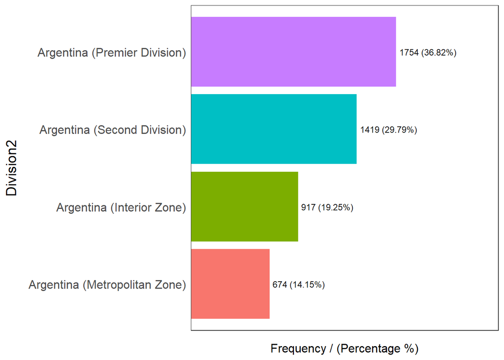

```
##                       Division2 frequency percentage cumulative_perc
## 1  Argentina (Premier Division)      1754      36.82           36.82
## 2   Argentina (Second Division)      1419      29.79           66.61
## 3     Argentina (Interior Zone)       917      19.25           85.86
## 4 Argentina (Metropolitan Zone)       674      14.15          100.00
```

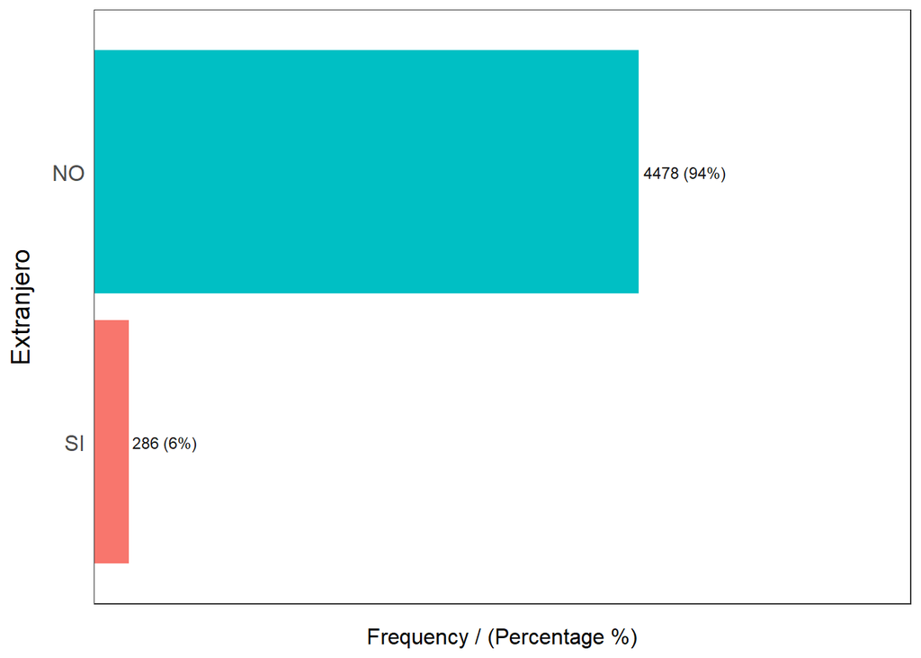

```
##   Extranjero frequency percentage cumulative_perc
## 1         NO      4478         94              94
## 2         SI       286          6             100
```

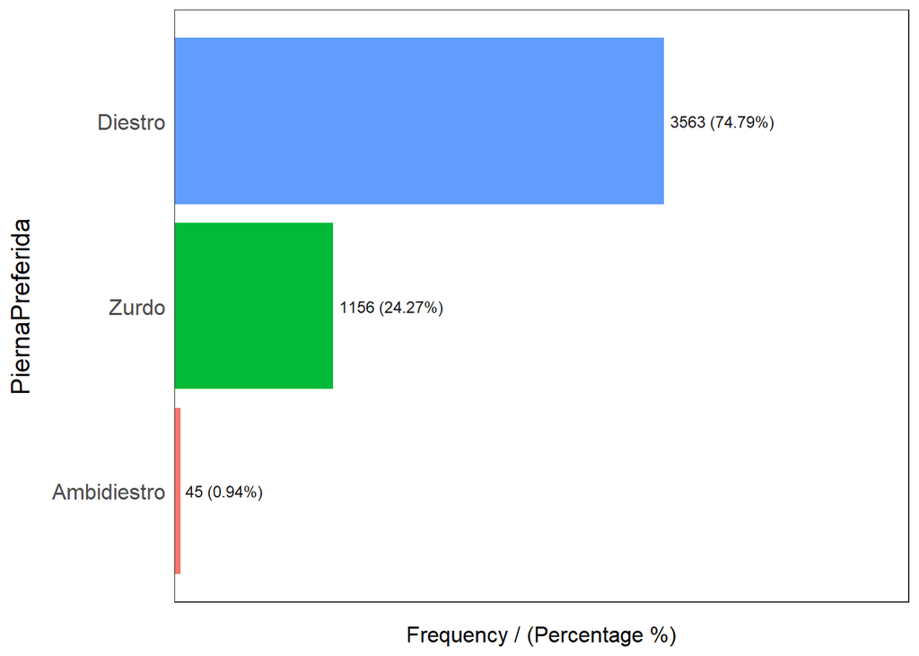

```
##   PiernaPreferida frequency percentage cumulative_perc
## 1         Diestro      3563      74.79           74.79
## 2           Zurdo      1156      24.27           99.06
## 3     Ambidiestro        45       0.94          100.00
```

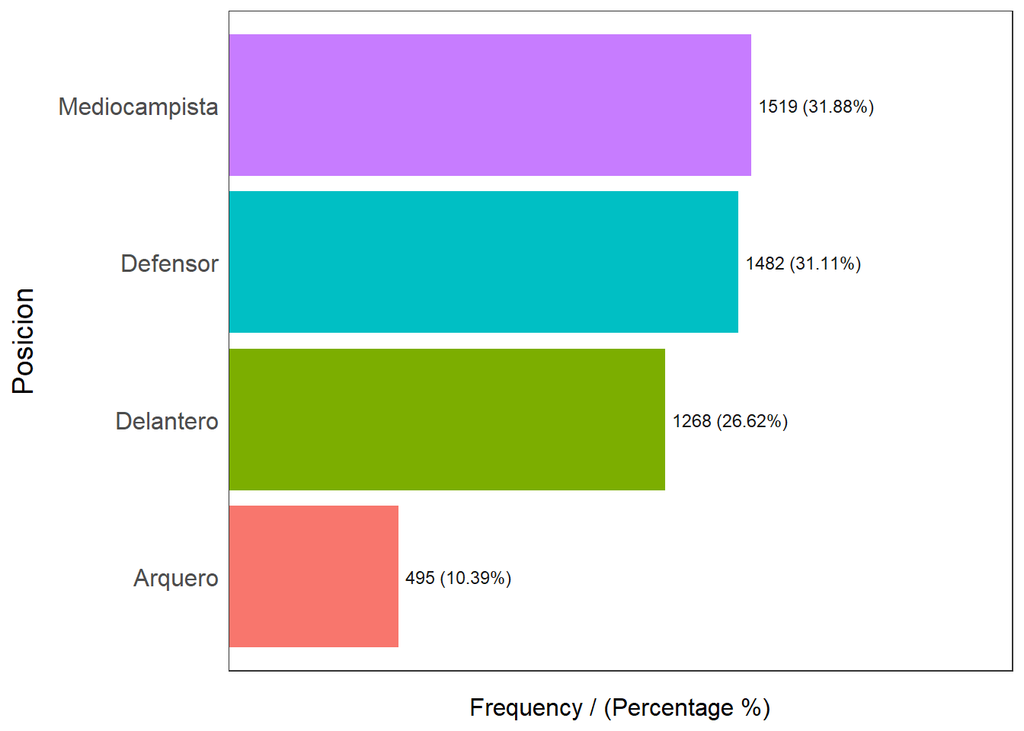

```
##        Posicion frequency percentage cumulative_perc
## 1 Mediocampista      1519      31.88           31.88
## 2      Defensor      1482      31.11           62.99
## 3     Delantero      1268      26.62           89.61
## 4       Arquero       495      10.39          100.00
```

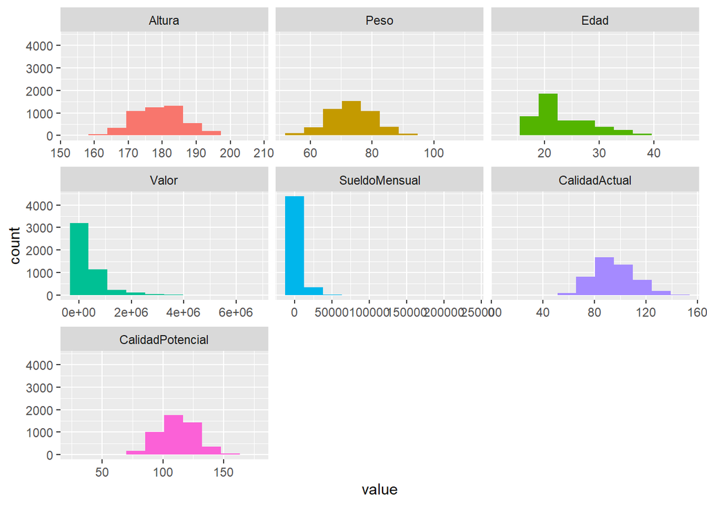

```
## data
##
##  11  Variables      4764  Observations
## --------------------------------------------------------------------------------
## Division2
##        n  missing distinct
##     4764        0        4
##
## Value          Argentina (Interior Zone) Argentina (Metropolitan Zone)
## Frequency                            917                           674
## Proportion                         0.192                         0.141
##
## Value       Argentina (Premier Division)   Argentina (Second Division)
## Frequency                           1754                          1419
## Proportion                         0.368                         0.298
## --------------------------------------------------------------------------------
## Extranjero
##        n  missing distinct
##     4764        0        2
##
## Value        NO   SI
## Frequency  4478  286
## Proportion 0.94 0.06
## --------------------------------------------------------------------------------
## Altura
##        n  missing distinct     Info     Mean      Gmd      .05      .10
##     4764        0       45    0.998    179.3    7.959      168      170
##      .25      .50      .75      .90      .95
##      175      179      184      188      191
##
## lowest : 153 156 157 158 159, highest: 195 196 197 198 203
## --------------------------------------------------------------------------------
## Peso
##        n  missing distinct     Info     Mean      Gmd      .05      .10
##     4764        0       48    0.998    73.46    8.108       62       65
##      .25      .50      .75      .90      .95
##       69       74       78       83       85
##
## lowest :  55  56  57  58  59, highest:  98  99 100 104 110
## --------------------------------------------------------------------------------
```

[output cut: 42 more lines]

```
##        n  missing distinct     Info     Mean      Gmd      .05      .10
##     4764        0       91    0.999    95.29    17.66       72       76
##      .25      .50      .75      .90      .95
##       84       94      106      116      122
##
## lowest :  13  40  52  53  54, highest: 140 142 143 144 145
## --------------------------------------------------------------------------------
## CalidadPotencial
##        n  missing distinct     Info     Mean      Gmd      .05      .10
##     4764        0       99    0.999    112.2    16.96       88       93
##      .25      .50      .75      .90      .95
##      102      112      122      131      137
##
## lowest :  38  67  68  69  70, highest: 165 167 169 171 178
## --------------------------------------------------------------------------------
```

```r
basic_eda(df_players_arg)
```

En el dataset predominan los jugadores diestros (casi 75%) ante los zurdos (casi 25%) y los ambidiestros (que son una rareza).

Las posiciones de Mediocampistas y Defensores son las más frecuentes en el conjunto de datos (poco más del 30%), los Arqueros son los menos frecuentes (cercanos al 10%) y los Delanteros tienen un porcentaje de aparición del 25%. Esto es esperable por como se dividen los jugadores en el campo de juego.

En cuanto a las divisiones, los jugadores se distribuyen en mayor proporción en las ligas de más categoría (esto puede ser ya que el juego se enfoca en las mejores ligas de cada país).

Lógicamente, la cantidad de jugadores nacionales es muy superior a la de extranjeros (94% vs 6%).

Para la calidad actual y la calidad potencial vemos que sus distribuciones son similares, pero con un corrimiento hacia valores más grandes en la potencial.

Por el lado del sueldo mensual y el valor del jugador, ambos presentan concentración en valores pequeños y pocas apariciones en valores altos.

### Correlaciones

Vemos la correlación de las variables numéricas

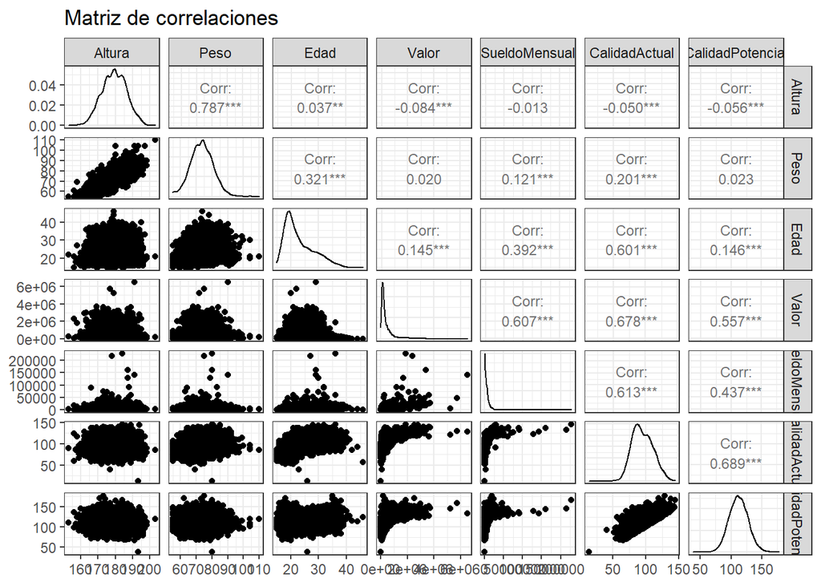

```r
variables_numericas =  purrr::map_lgl(df_players_arg, is.numeric)
df_num = df_players_arg[,variables_numericas]

df_num %>%
  GGally::ggpairs(.,
                  title = "Matriz de correlaciones",
                  upper = list(continuous = wrap("cor", size = 3, hjust=0.5))
                  ) +
  theme_bw()
```

Existe una alta correlación lineal positiva (0.78) entre el peso y la altura de los jugadores. También existe cierta correlación lineal entre la calidad actual y la calidad potencial, llegando a casi 0.7. Por último, hay cierta relación lineal entre el valor y la calidad actual, y entre el valor y el sueldo mensual, pero menores a los casos anteriores.

## 3) Ajustamos modelos

### Modelo inicial

Separamos el dataset en entrenamiento y test

```r
trainIndex = caret::createDataPartition(y = df_players_arg$SueldoMensual,
                                        p = 0.75,
                                        list = FALSE,
                                        times = 1)
ds_train = df_players_arg[ trainIndex,]
ds_test  = df_players_arg[-trainIndex,]
ds_test_x = ds_test[,setdiff(names(ds_test),c("SueldoMensual"))]
ds_test_y = ds_test$SueldoMensual
```

Generamos un modelo con todas las variables con *rpart*

```r
modelo1 <- rpart(
  formula = SueldoMensual ~ . ,
  data    = ds_train
  )
```

Mostramos como quedó el árbol

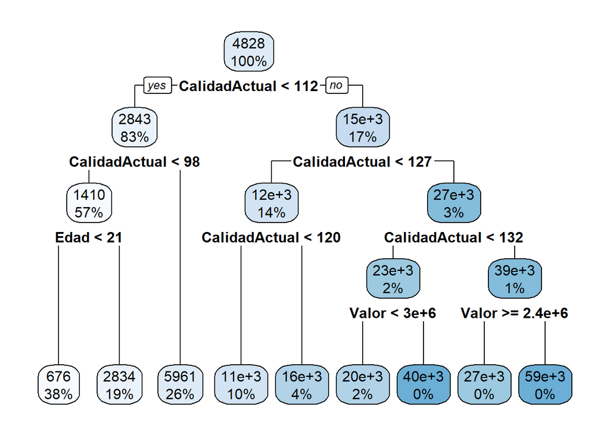

```r
rpart.plot(modelo1)
```

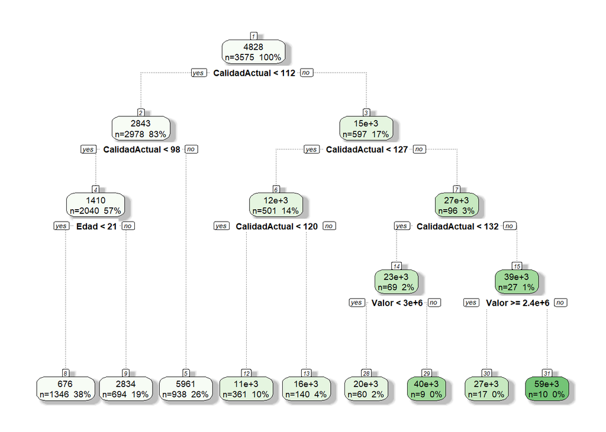

```r
fancyRpartPlot(modelo1,yesno=2,split.col="black",nn.col="black",
               caption="",branch.col="black")
```

Vemos el resumen del modelo ajustado

```r
summary(modelo1)
```

```
## Call:
## rpart(formula = SueldoMensual ~ ., data = ds_train)
##   n= 3575
##
##           CP nsplit rel error    xerror      xstd
## 1 0.33140492      0 1.0000000 1.0002961 0.2479900
## 2 0.08767036      1 0.6685951 0.6788555 0.2190244
## 3 0.06279659      2 0.5809247 0.6257347 0.2178689
## 4 0.02713868      3 0.5181281 0.5535565 0.2028139
## 5 0.01570084      5 0.4638508 0.5636684 0.2028705
## 6 0.01382353      6 0.4481499 0.5324265 0.1810800
## 7 0.01006085      7 0.4343264 0.5346489 0.1814000
## 8 0.01000000      8 0.4242655 0.5245054 0.1813877
##
## Variable importance
##    CalidadActual            Valor CalidadPotencial             Edad
##               56               30                9                5
##
## Node number 1: 3575 observations,    complexity param=0.3314049
##   mean=4827.866, MSE=5.92873e+07
##   left son=2 (2978 obs) right son=3 (597 obs)
##   Primary splits:
##       CalidadActual    < 111.5   to the left,  improve=0.3314049, (0 missing)
##       Valor            < 1050000 to the left,  improve=0.2969616, (0 missing)
##       CalidadPotencial < 129.5   to the left,  improve=0.1794592, (0 missing)
##       Edad             < 20.5    to the left,  improve=0.1563879, (0 missing)
##       Division2        splits as  LLRL,        improve=0.0160372, (0 missing)
##   Surrogate splits:
##       Valor            < 937500  to the left,  agree=0.924, adj=0.543, (0 split)
##       CalidadPotencial < 129.5   to the left,  agree=0.865, adj=0.193, (0 split)
##       Altura           < 158.5   to the right, agree=0.833, adj=0.002, (0 split)
##
## Node number 2: 2978 observations,    complexity param=0.06279659
##   mean=2843.21, MSE=8100067
##   left son=4 (2040 obs) right son=5 (938 obs)
##   Primary splits:
##       CalidadActual    < 97.5    to the left,  improve=0.55177310, (0 missing)
##       Edad             < 20.5    to the left,  improve=0.39817470, (0 missing)
##       Valor            < 287500  to the left,  improve=0.25256060, (0 missing)
##       CalidadPotencial < 103.5   to the left,  improve=0.10894280, (0 missing)
```

[output cut: 97 more lines]

```
##       Edad     < 27.5    to the right, improve=0.05080442, (0 missing)
##   Surrogate splits:
##       Edad < 31.5    to the left,  agree=0.815, adj=0.5, (0 split)
##
## Node number 28: 60 observations
##   mean=20473.33, MSE=7.728396e+07
##
## Node number 29: 9 observations
##   mean=39822.22, MSE=1.389853e+09
##
## Node number 30: 17 observations
##   mean=26929.41, MSE=6.946796e+07
##
## Node number 31: 10 observations
##   mean=59280, MSE=3.492986e+09
```

Para ver un poco mejor la importancia de las variables, haremos el siguiente gráfico

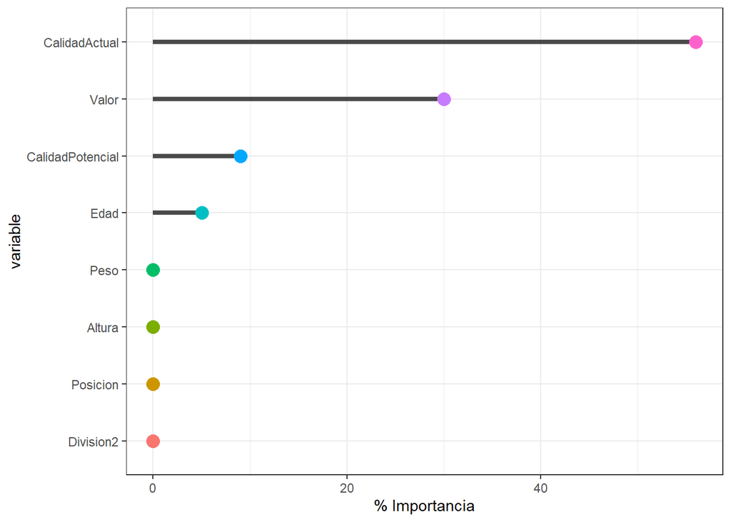

```r
variable_importance1  = modelo1$variable.importance
variable_importance1 = data.frame(importance = round(variable_importance1 / sum(variable_importance1) * 100)) %>%
  tibble::rownames_to_column() %>%
  dplyr::rename("variable" = rowname) %>%
  dplyr::arrange(importance) %>%
  dplyr::mutate(variable = forcats::fct_inorder(variable))

ggplot(variable_importance1) +
  geom_segment(aes(x = variable, y = 0, xend = variable, yend = importance),
               size = 1.5, alpha = 0.7) +
  geom_point(aes(x = variable, y = importance, col = variable),
             size = 4, show.legend = F) +
  coord_flip() +
  ylab("% Importancia") +
  theme_bw()
```

Observamos en el ranking que las variables mas importantes son la calidad actual, el valor, la calidad potencial y la edad.

Miremos las reglas, pero ordenadas en un dataframe

```r
rpart.rules(modelo1, roundint = FALSE, clip.facs = TRUE)
```

|  | SueldoMensual |  |  |  |  |  |  |  |  |  |  |  |  |  |  |
| --- | --- | --- | --- | --- | --- | --- | --- | --- | --- | --- | --- | --- | --- | --- | --- |
| 8 | 676 | when | CalidadActual | < | 98 |  |  |  |  |  |  | & | Edad | < | 21 |
| 9 | 2834 | when | CalidadActual | < | 98 |  |  |  |  |  |  | & | Edad | >= | 21 |
| 5 | 5961 | when | CalidadActual | is | 98 | to | 112 |  |  |  |  |  |  |  |  |
| 12 | 10681 | when | CalidadActual | is | 112 | to | 120 |  |  |  |  |  |  |  |  |
| 13 | 16424 | when | CalidadActual | is | 120 | to | 127 |  |  |  |  |  |  |  |  |
| 28 | 20473 | when | CalidadActual | is | 127 | to | 132 | & | Valor | < | 2950000 |  |  |  |  |
| 30 | 26929 | when | CalidadActual | >= |  |  | 132 | & | Valor | >= | 2450000 |  |  |  |  |
| 29 | 39822 | when | CalidadActual | is | 127 | to | 132 | & | Valor | >= | 2950000 |  |  |  |  |
| 31 | 59280 | when | CalidadActual | >= |  |  | 132 | & | Valor | < | 2450000 |  |  |  |  |

Así es más facíl comprender el proceso de evaluación de una nueva observación.

### Modelo *cp=0*

*rpart* pone un valor por defecto al parámetro *cp*, veamos que sucede si lo ponemos en 0. Para que el árbol pueda crecer libre, sobreescribo los valores de parámetros por defecto de *minsplit* y *minbucket* con valor 1

```r
modelo2 <- rpart(
  formula = SueldoMensual ~ . ,
  data    = ds_train,
  control = list(cp = 0, minsplit = 1, minbucket = 1)
  )
```

Mostramos como quedó el árbol

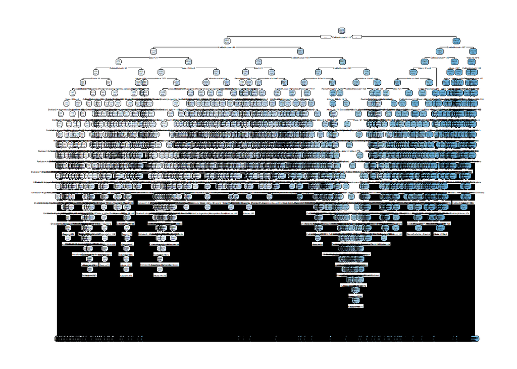

```r
rpart.plot(modelo2)
```

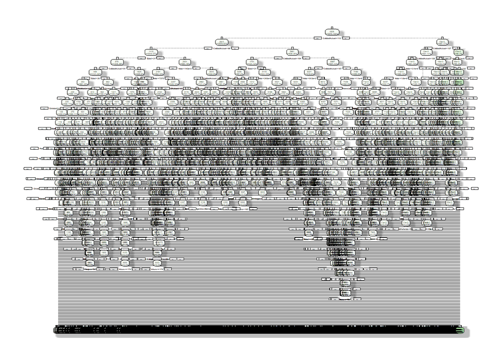

```r
fancyRpartPlot(modelo2,yesno=2,split.col="black",nn.col="black",
               caption="",branch.col="black")
```

El gráfico es muy extenso, lo que dificulta su lectura y comprensión. Confirmamos así que crece altamente la cantidad de nodos hojas al no utilizar el parámetro CP, dejando al árbol crecer libremente.

Vemos la importancia de las variables

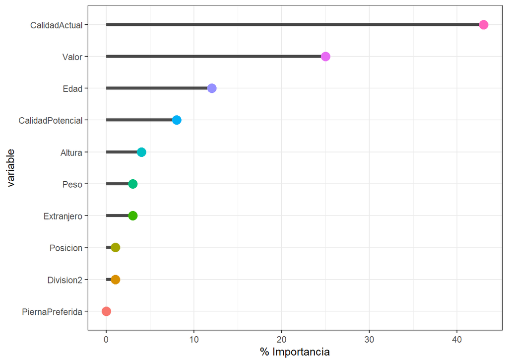

```r
variable_importance2  = modelo2$variable.importance
variable_importance2 = data.frame(importance = round(variable_importance2 / sum(variable_importance2) * 100)) %>%
  tibble::rownames_to_column() %>%
  dplyr::rename("variable" = rowname) %>%
  dplyr::arrange(importance) %>%
  dplyr::mutate(variable = forcats::fct_inorder(variable))

ggplot(variable_importance2) +
  geom_segment(aes(x = variable, y = 0, xend = variable, yend = importance),
               size = 1.5, alpha = 0.7) +
  geom_point(aes(x = variable, y = importance, col = variable),
             size = 4, show.legend = F) +
  coord_flip() +
  ylab("% Importancia") +
  theme_bw()
```

Observamos que en el gráfico cambia levemnete el valor de las variables que menos importancia tienen

Como ver el árbol generado se dificulta, vemos cuantas hojas se generaron

```r
sum(modelo2$frame$var == "<leaf>")
```

```
## [1] 2118
```

Además, observamos las veces que las variables se usaron como corte

```r
df_variables_2 = as.data.frame(modelo2$frame$var[modelo2$frame$var != "<leaf>"])
names(df_variables_2) = c("variable")
df_variables_2 %>%
  group_by(variable) %>%
  dplyr::summarise(n = n()) %>%
  mutate(freq = round(n / sum(n),3)) %>%
  arrange(-n)
```

| variable | n | freq |
| --- | --- | --- |
| Altura | 668 | 0.316 |
| Division2 | 287 | 0.136 |
| Valor | 246 | 0.116 |
| Peso | 220 | 0.104 |
| CalidadPotencial | 173 | 0.082 |
| Edad | 173 | 0.082 |
| CalidadActual | 129 | 0.061 |
| Posicion | 121 | 0.057 |
| Extranjero | 57 | 0.027 |
| PiernaPreferida | 43 | 0.020 |

### Modelo *cp ok*

Un último paso que hacemos en esta sección es buscar, por cross validation, el mejor valor para el parámetro CP.

```r
set.seed(seed)
train.control <- caret::trainControl(
  method = "cv",
  number = 10
  )

busqueda_cp <- train(
  x = dplyr::select(ds_train, -c("SueldoMensual")),
  y = ds_train$SueldoMensual,
  method = "rpart",
  tuneLength = 100,
  trControl = train.control
  )

busqueda_cp$bestTune
```

|  | cp |
| --- | --- |
| 16 | 5.592977e-05 |

```r
modelo3 = rpart(
  formula = SueldoMensual ~ . ,
  data    = ds_train,
  control = list(cp = busqueda_cp$bestTune[1,1])
  )
```

Luego revisamos como quedó el ábol

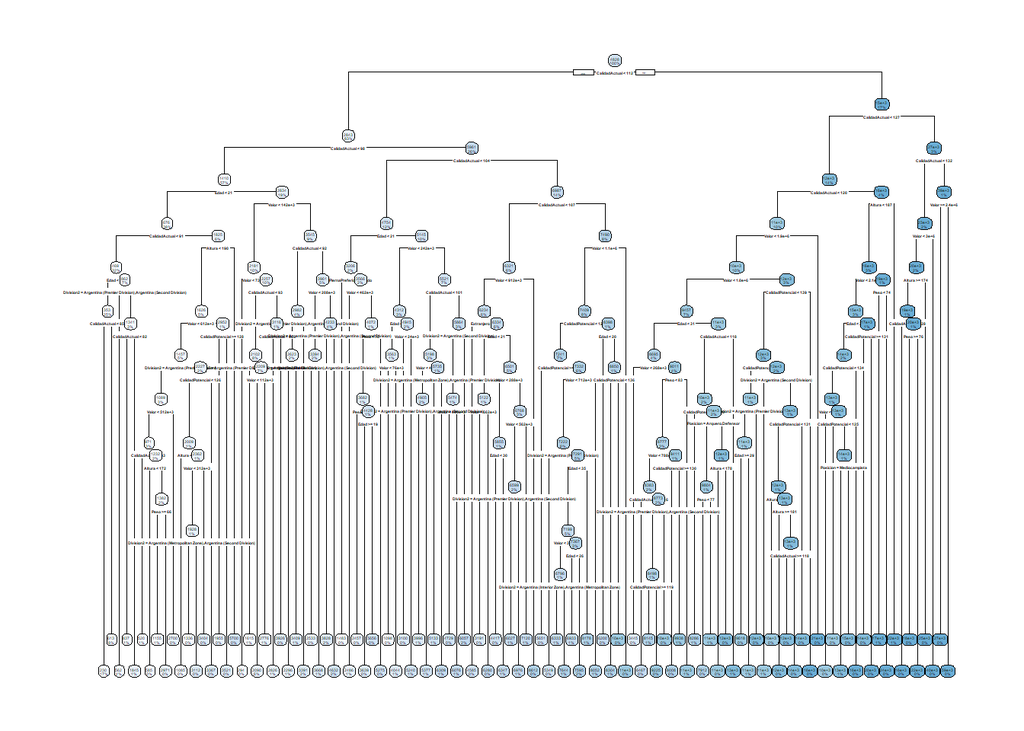

```r
rpart.plot(modelo3)
```

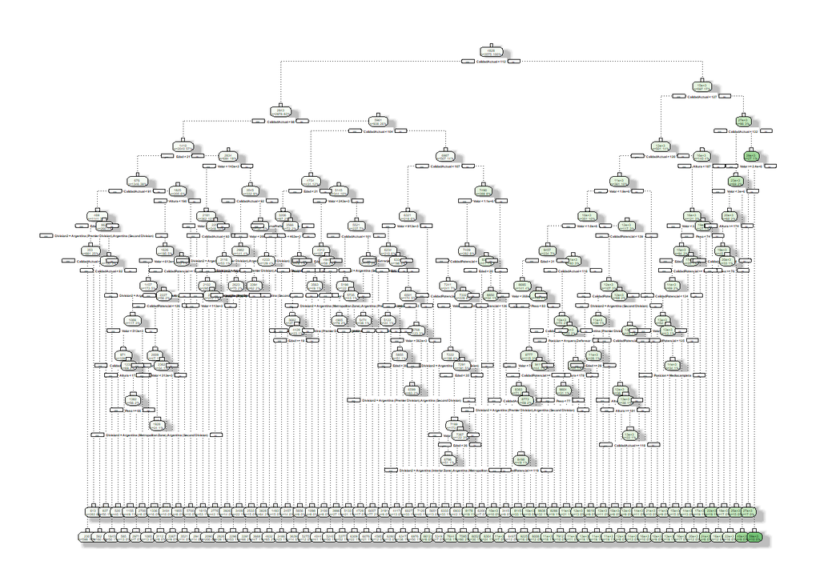

```r
fancyRpartPlot(modelo3,yesno=2,split.col="black",nn.col="black",
               caption="",branch.col="black")
```

Como ver el árbol generado se dificulta nuevamente, vemos cuantas hojas se generaron

```r
sum(modelo3$frame$var == "<leaf>")
```

```
## [1] 111
```

Una baja considerable con respecto al anterior

Vemos la importancia de las variables

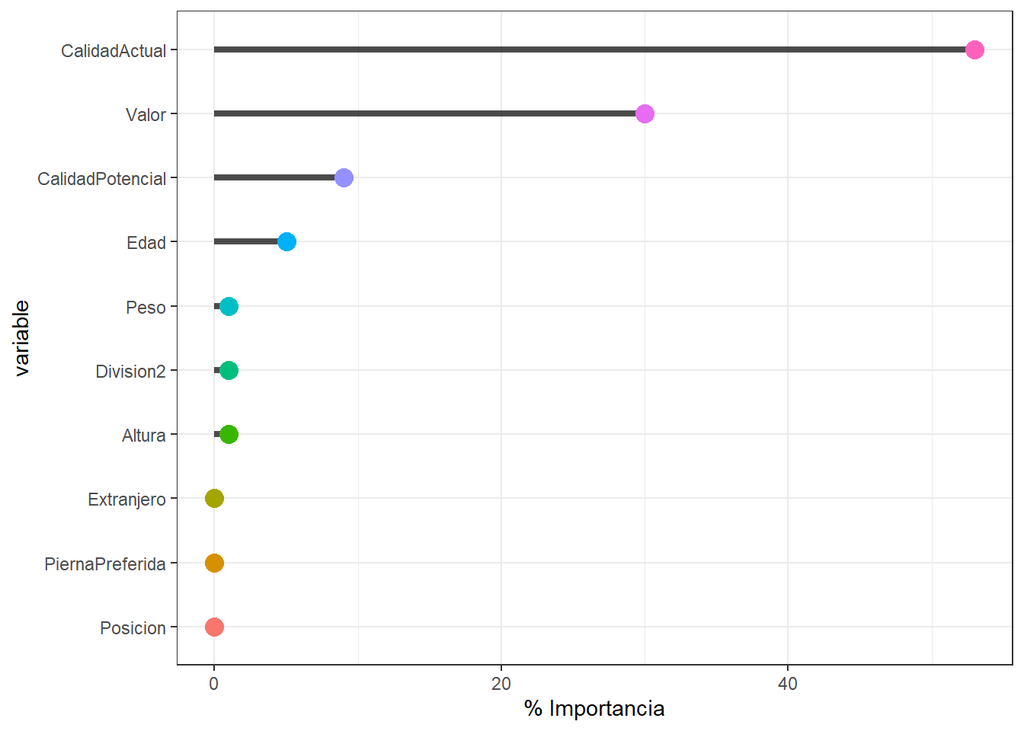

```r
variable_importance3  = modelo3$variable.importance
variable_importance3 = data.frame(importance = round(variable_importance3 / sum(variable_importance3) * 100)) %>%
  tibble::rownames_to_column() %>%
  dplyr::rename("variable" = rowname) %>%
  dplyr::arrange(importance) %>%
  dplyr::mutate(variable = forcats::fct_inorder(variable))

ggplot(variable_importance3) +
  geom_segment(aes(x = variable, y = 0, xend = variable, yend = importance),
               size = 1.5, alpha = 0.7) +
  geom_point(aes(x = variable, y = importance, col = variable),
             size = 4, show.legend = F) +
  coord_flip() +
  ylab("% Importancia") +
  theme_bw()
```

Como antes, observamos las veces que las variables se usaron como corte

```r
df_variables_3 = as.data.frame(modelo3$frame$var[modelo3$frame$var != "<leaf>"])
names(df_variables_3) = c("variable")
df_variables_3 %>%
  group_by(variable) %>%
  dplyr::summarise(n = n()) %>%
  mutate(freq = round(n / sum(n),3)) %>%
  arrange(-n)
```

| variable | n | freq |
| --- | --- | --- |
| Valor | 29 | 0.264 |
| CalidadActual | 19 | 0.173 |
| Division2 | 16 | 0.145 |
| CalidadPotencial | 14 | 0.127 |
| Edad | 13 | 0.118 |
| Altura | 8 | 0.073 |
| Peso | 7 | 0.064 |
| Posicion | 2 | 0.018 |
| Extranjero | 1 | 0.009 |
| PiernaPreferida | 1 | 0.009 |

## 4) Generando otros modelos

### Modelo *minsplit*

Generamos un modelo, pero esta vez sacando la variable *CalidadActual* que fue muy importante para el primer modelo. Además agregaremos un control sobre el campo *minsplit*

```r
modelo4 <- rpart(
  formula = SueldoMensual ~ . - CalidadActual,
  data    = ds_train,
  control = rpart.control(minsplit = 200)
  )
```

Mostramos como quedó el árbol

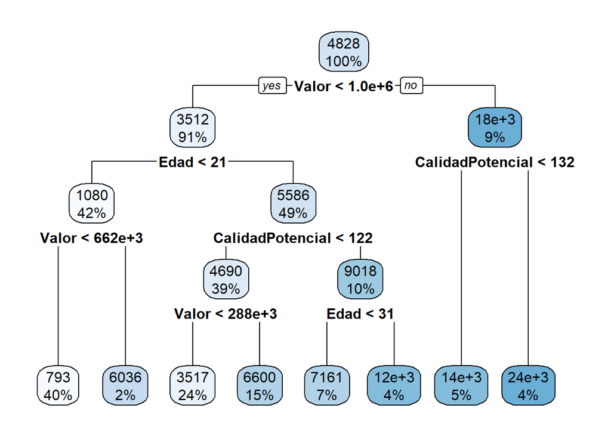

```r
rpart.plot(modelo4)
```

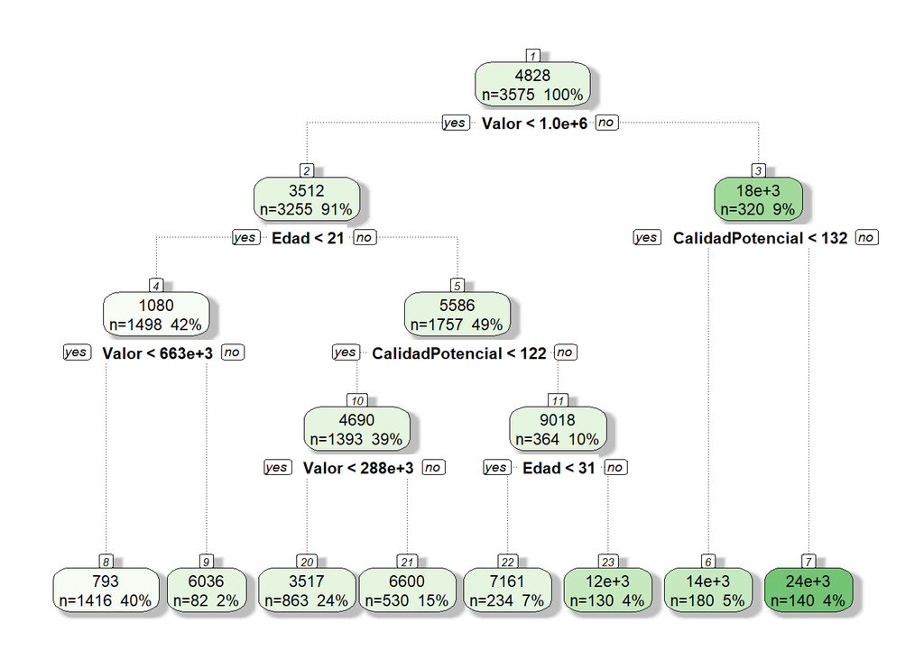

```r
fancyRpartPlot(modelo4,yesno=2,split.col="black",nn.col="black",
               caption="",branch.col="black")
```

Vemos el resumen del modelo ajustado

```r
summary(modelo4)
```

```
## Call:
## rpart(formula = SueldoMensual ~ . - CalidadActual, data = ds_train,
##     control = rpart.control(minsplit = 200))
##   n= 3575
##
##           CP nsplit rel error    xerror      xstd
## 1 0.29696156      0 1.0000000 1.0005757 0.2480073
## 2 0.07748386      1 0.7030384 0.7147523 0.2145069
## 3 0.04185941      2 0.6255546 0.6399944 0.2153545
## 4 0.02550669      3 0.5836952 0.6131504 0.2000337
## 5 0.01472354      4 0.5581885 0.5900247 0.1999130
## 6 0.01065260      5 0.5434649 0.5757667 0.1994148
## 7 0.01005384      6 0.5328123 0.5671559 0.1995831
## 8 0.01000000      7 0.5227585 0.5663533 0.1995834
##
## Variable importance
##            Valor             Edad CalidadPotencial        Division2
##               59               16               15                6
##             Peso           Altura       Extranjero
##                3                1                1
##
## Node number 1: 3575 observations,    complexity param=0.2969616
##   mean=4827.866, MSE=5.92873e+07
##   left son=2 (3255 obs) right son=3 (320 obs)
##   Primary splits:
##       Valor            < 1050000 to the left,  improve=0.2969616, (0 missing)
##       CalidadPotencial < 129.5   to the left,  improve=0.1794592, (0 missing)
##       Edad             < 20.5    to the left,  improve=0.1563879, (0 missing)
##       Division2        splits as  LLRL,        improve=0.0160372, (0 missing)
##       Extranjero       splits as  LR,          improve=0.0114595, (0 missing)
##   Surrogate splits:
##       CalidadPotencial < 139.5   to the left,  agree=0.914, adj=0.034, (0 split)
##       Altura           < 158.5   to the right, agree=0.911, adj=0.003, (0 split)
##
## Node number 2: 3255 observations,    complexity param=0.07748386
##   mean=3512.246, MSE=1.463332e+07
##   left son=4 (1498 obs) right son=5 (1757 obs)
##   Primary splits:
##       Edad             < 20.5    to the left,  improve=0.34479040, (0 missing)
##       Valor            < 287500  to the left,  improve=0.20486530, (0 missing)
```

[output cut: 89 more lines]

```
##       CalidadPotencial < 135.5   to the left,  agree=0.706, adj=0.177, (0 split)
##       Peso             < 84.5    to the left,  agree=0.673, adj=0.085, (0 split)
##       Altura           < 189.5   to the left,  agree=0.657, adj=0.038, (0 split)
##
## Node number 20: 863 observations
##   mean=3516.663, MSE=3835449
##
## Node number 21: 530 observations
##   mean=6599.547, MSE=3947155
##
## Node number 22: 234 observations
##   mean=7161.453, MSE=1.650301e+07
##
## Node number 23: 130 observations
##   mean=12359.23, MSE=3.29118e+07
```

Vemos la importancia de las variables para este modelo

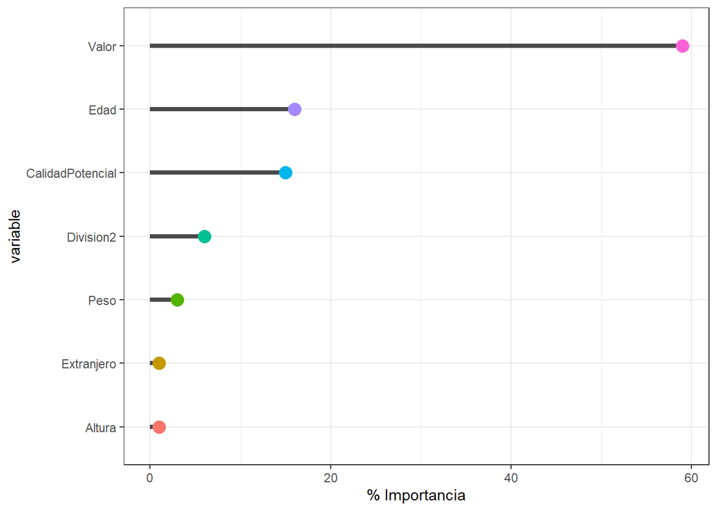

```r
variable_importance4  = modelo4$variable.importance
variable_importance4 = data.frame(importance = round(variable_importance4 / sum(variable_importance4) * 100)) %>%
  tibble::rownames_to_column() %>%
  dplyr::rename("variable" = rowname) %>%
  dplyr::arrange(importance) %>%
  dplyr::mutate(variable = forcats::fct_inorder(variable))

ggplot(variable_importance4) +
  geom_segment(aes(x = variable, y = 0, xend = variable, yend = importance),
               size = 1.5, alpha = 0.7) +
  geom_point(aes(x = variable, y = importance, col = variable),
             size = 4, show.legend = F) +
  coord_flip() +
  ylab("% Importancia") +
  theme_bw()
```

Observamos que al quitar la variable más usada anteriormente, las demás cobran más importancia. Si los comparamos, vemos que la edad subió en importancia y pasó a la calidad potencial.

Vemos las reglas como dataframe

```r
rpart.rules(modelo4, roundint = FALSE, clip.facs = TRUE)
```

|  | SueldoMensual |  |  |  |  |  |  |  |  |  |  |  |  |  |  |  |  |
| --- | --- | --- | --- | --- | --- | --- | --- | --- | --- | --- | --- | --- | --- | --- | --- | --- | --- |
| 8 | 793 | when | Valor | < | 662500 |  |  |  |  |  |  | & | Edad | < | 21 |  |  |
| 20 | 3517 | when | Valor | < | 287500 |  |  | & | CalidadPotencial | < | 122 | & | Edad | >= |  |  | 21 |
| 9 | 6036 | when | Valor | is | 662500 | to | 1050000 |  |  |  |  | & | Edad | < | 21 |  |  |
| 21 | 6600 | when | Valor | is | 287500 | to | 1050000 | & | CalidadPotencial | < | 122 | & | Edad | >= |  |  | 21 |
| 22 | 7161 | when | Valor | < | 1050000 |  |  | & | CalidadPotencial | >= | 122 | & | Edad | is | 21 | to | 31 |
| 23 | 12359 | when | Valor | < | 1050000 |  |  | & | CalidadPotencial | >= | 122 | & | Edad | >= |  |  | 31 |
| 6 | 13566 | when | Valor | >= |  |  | 1050000 | & | CalidadPotencial | < | 132 |  |  |  |  |  |  |
| 7 | 24181 | when | Valor | >= |  |  | 1050000 | & | CalidadPotencial | >= | 132 |  |  |  |  |  |  |

### Modelo *maxdepth*

Luego, generamos otro modelo, pero esta vez sacando las variables *CalidadActual*, *CalidadPotencial* y *Valor*. Además estableceremos que no tenga una profundidad mayor a 4.

```r
modelo5 <- rpart(
  formula = SueldoMensual ~ . - CalidadActual - CalidadPotencial - Valor,
  data    = ds_train,
  control = rpart.control(maxdepth = 4)
  )
```

Mostramos como quedó el árbol

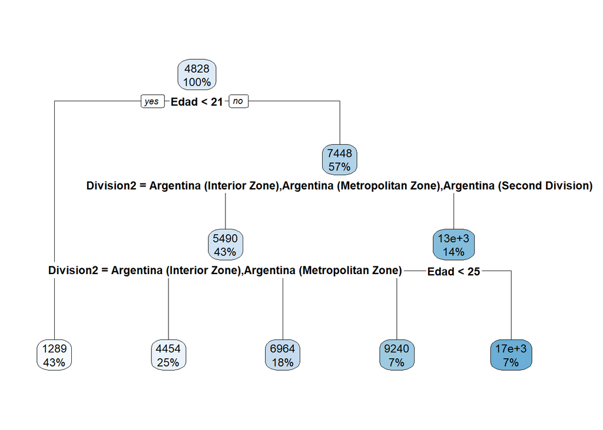

```r
rpart.plot(modelo5)
```

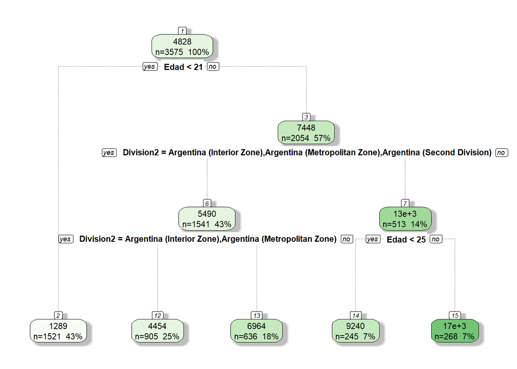

```r
fancyRpartPlot(modelo5,yesno=2,split.col="black",nn.col="black",
               caption="",branch.col="black")
```

Estudiamos la importcancia de variables de este nuevo árbol

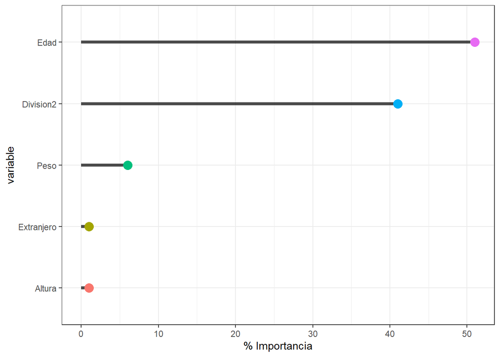

```r
variable_importance5  = modelo5$variable.importance
variable_importance5 = data.frame(importance = round(variable_importance5 / sum(variable_importance5) * 100)) %>%
  tibble::rownames_to_column() %>%
  dplyr::rename("variable" = rowname) %>%
  dplyr::arrange(importance) %>%
  dplyr::mutate(variable = forcats::fct_inorder(variable))

ggplot(variable_importance5) +
  geom_segment(aes(x = variable, y = 0, xend = variable, yend = importance),
               size = 1.5, alpha = 0.7) +
  geom_point(aes(x = variable, y = importance, col = variable),
             size = 4, show.legend = F) +
  coord_flip() +
  ylab("% Importancia") +
  theme_bw()
```

Como se ve en el árbol, la edad y la división son las que más importancia toman

Vemos las reglas como dataframe

```r
rpart.rules(modelo5, roundint = FALSE, clip.facs = TRUE)
```

|  | SueldoMensual |  |  |  |  |  |  |  |  |
| --- | --- | --- | --- | --- | --- | --- | --- | --- | --- |
| 2 | 1289 | when | Edad | < | 21 |  |  |  |  |
| 12 | 4454 | when | Edad | >= |  |  | 21 | & | Argentina (Interior Zone) or Argentina (Metropolitan Zone) |
| 13 | 6964 | when | Edad | >= |  |  | 21 | & | Argentina (Second Division) |
| 14 | 9240 | when | Edad | is | 21 | to | 25 | & | Argentina (Premier Division) |
| 15 | 17070 | when | Edad | >= |  |  | 25 | & | Argentina (Premier Division) |

Vemos que en este ajuste de modelo se generaron menos hojas que en los modelos anteriores.

## 5) Comprobremos la performance

### Modelos lineales

Primero, a fines comparativos, generamos un modelo lineal con todas las variables

```r
modelolm <- lm(SueldoMensual ~ ., data = ds_train)
```

Con el mismo fin, ajustamos un modelo lineal pero esta vez robusto

```r
modelolmrobusto <- MASS::rlm(SueldoMensual ~ ., data = ds_train)
```

### Predicciones

Organizamos los modelos a evaluar en una lista

```r
modelos = list(
  modelo_inicial = modelo1,
  modelo_cp0 = modelo2,
  modelo_cpok = modelo3,
  modelo_minsplit = modelo4,
  modelo_maxdepth = modelo5,
  modelo_lm = modelolm,
  modelo_lmrobusto = modelolmrobusto
)
```

Obtenemos las predicciones

```r
lista_predicciones_test = map(.x = modelos, .f = predict, newdata = ds_test)
```

Agrego la predicción a cada modelo

```r
add_row <- function(pred,data)
{
  return( cbind(data,pred) )
}

ds_test_preds = map(.x = lista_predicciones_test, .f = add_row, data = ds_test)
```

### RMSE

Calculamos el RMSE (raíz del error cuadrático medio) para los modelos ajustados

```r
map_dfr(.x = ds_test_preds, .f = yardstick::rmse, truth = SueldoMensual, estimate = pred, .id="modelo") %>% arrange(.estimate)
```

| modelo | .metric | .estimator | .estimate |
| --- | --- | --- | --- |
| modelo_cpok | rmse | standard | 7490.700 |
| modelo_inicial | rmse | standard | 7493.343 |
| modelo_lm | rmse | standard | 7602.002 |
| modelo_lmrobusto | rmse | standard | 7757.648 |
| modelo_minsplit | rmse | standard | 7885.816 |
| modelo_maxdepth | rmse | standard | 8408.243 |
| modelo_cp0 | rmse | standard | 12805.454 |

Vemos que para esta métrica el modelo para el cual buscamos el mejor Cp es mejor, acompañado muy de cerca por el primero generado. Ambos obtuvieron un mejor rendimiento para esta métrica que los lineales, mientras que los restantes modelos de árboles (a los que le quitamos variables importantes y al que crece libre) tienen performance baja.

### MAE

Calculamos el MAE (error absoluto medio) para los modelos ajustados

```r
map_dfr(.x = ds_test_preds, .f = yardstick::mae, truth = SueldoMensual, estimate = pred, .id="modelo") %>% arrange(.estimate)
```

| modelo | .metric | .estimator | .estimate |
| --- | --- | --- | --- |
| modelo_lmrobusto | mae | standard | 1677.572 |
| modelo_cpok | mae | standard | 1771.832 |
| modelo_lm | mae | standard | 1816.985 |
| modelo_inicial | mae | standard | 1986.140 |
| modelo_minsplit | mae | standard | 2168.353 |
| modelo_cp0 | mae | standard | 2623.904 |
| modelo_maxdepth | mae | standard | 2780.496 |

Para el MAE, el modelo lineal robusto es el que mejor rendimiento obtuvo, seguido del modelo para el cual buscamos el mejor CP. Los restantes modelos de árboles tienen también pobre performance bajo esta métrica.